# Lab 7 Arrays and Pandas Dataframe

#### **3 Matrix Calculation**

**Very important: To do any calculation right, you have to check the dimensions of the two arrays that you are calculating**

- matrix addition and substraction is possible as long as matrices have the same dimensions.
- operator * does not do matrix multiplication but rather element-wise multiplication
- matrix multiplication done through **@**

**3.1 Addition/Subtraction**

Matrices MUST have the same dimension

```python
# for matrics
a = np.array([[4, 9, 8],
              [2, 6, 3]])
b = np.array([[1, 5, 2],
              [6, 6, 0],
              [4, 8, 3]])

print(f'Does a and b have the same dimention? {np.shape(b) == np.shape(a)}')
# np.add(a+b) or a + b
a + b
# fail because dimensions are different
```

```
Does a and b have the same dimention? False
```

```
---------------------------------------------------------------------------
ValueError                                Traceback (most recent call last)
Cell In [69], line 10
      8 print(f'Does a and b have the same dimention? {np.shape(b) == np.shape(a)}')
      9 # np.add(a+b) or a + b
---> 10 a + b
     11 # fail because dimensions are different

ValueError: operands could not be broadcast together with shapes (2,3) (3,3)
```

Now we just need to subset b, so that it would have the same dimension as a.

```python
# always do a dimension test
np.shape(b[[0,1]]) == np.shape(a)
```

```
True
```

```python
# a add part of b, now both have the same dimension.
np.add(a, b[[0,1]])
```

```
array([[ 5, 14, 10],
       [ 8, 12,  3]])
```

```python
# for matrics
a = np.array([[4, 9, 8],
              [2, 6, 3]])
b = np.array([[1, 5, 2],
              [6, 6, 0],
              [4, 8, 3]])
# subsetting b, store in b1, so that np.shape(b1) == np.shape(a)
b1 =  b[[0,1]]
# np.subtract(a, b) or a - b
a - b1
```

```
array([[ 3,  4,  6],
       [-4,  0,  3]])
```

**3.2 Multiplication/Division** a * b or a/b does NOT do matrix multiplication, but only element wise multiplication. In other words they only multiply each corresponding element of the two matrix, therefore the dimensions still need to match.

```python
# np.multiply(a, b) or a*b
if np.shape(a) == np.shape(b1):
    print(a * b1)
```

```
[[ 4 45 16]
 [12 36  0]]
```

```python
# np.divide (a, b) or a/b
if np.shape(a) == np.shape(b1):
    print(a / b1)
```

```
[[4.         1.8        4.        ]
 [0.33333333 1.                inf]]
```

**3.3 Other common 2d-array methods**

```python
a = np.array([[4, 9, 8],
              [2, 6, 3]])
b = np.array([[1, 5, 2],
              [6, 6, 0],
              [4, 8, 3]])

# exponentiate
expo = np.exp(a)
print(f'np.exp(a) raises e to the ath power:\n {expo}')

# take square roots
sr = np.sqrt(a)
print(f'np.sqrt(a) takes the square root of a: \n{sr}')

# take log
loga = np.log(a)
print(f'np.log(a) takes the log of a: \n{loga}')

# inverse of a
inv = np.linalg.inv(b)
print(f'np.linalg.inv(b) takes the inverse of a: \n{inv}')

# sum of a
s = a.sum()
print(f'a.sum() takes the sum of a: \n{s}')

# min of a
min = a.min()
print(f'a.min() takes the minimum element of a: \n{min}')
```

```
np.exp(a) raises e to the ath power:
 [[5.45981500e+01 8.10308393e+03 2.98095799e+03]
 [7.38905610e+00 4.03428793e+02 2.00855369e+01]]
np.sqrt(a) takes the square root of a:
[[2.         3.         2.82842712]
 [1.41421356 2.44948974 1.73205081]]
np.log(a) takes the log of a:
[[1.38629436 2.19722458 2.07944154]
 [0.69314718 1.79175947 1.09861229]]
np.linalg.inv(b) takes the inverse of a:
[[-0.75       -0.04166667  0.5       ]
 [ 0.75        0.20833333 -0.5       ]
 [-1.         -0.5         1.        ]]
a.sum() takes the sum of a:
32
a.min() takes the minimum element of a:
2
```

```python
# matrix multiplication of a and b: inner dimension must match
# therefore cannot switch orders
product_ab = a.dot(b)
a@b
print(f"""Multiplication: the inner dimension must match when using a.dot(b)
to multiply matrix a and b. For this reason, b.dot(a) won't work: \n {product_ab}""")


# transpose
ta = a.transpose()
print(f'For given matrix a with dimension {np.shape(a)}: \n{a}')
print(f'a.transpose() turns the dimensions of a around (a.T also works): \n{ta}\n Now the dimension becomes {np.shape(ta)}.')
```

```
Multiplication: the inner dimension must match when using a.dot(b)
to multiply matrix a and b. For this reason, b.dot(a) won't work:
 [[ 90 138  32]
 [ 50  70  13]]
For given matrix a with dimension (2, 3):
[[4 9 8]
 [2 6 3]]
a.transpose() turns the dimensions of a around (a.T also works):
[[4 2]
 [9 6]
 [8 3]]
 Now the dimension becomes (3, 2).
```

#### **4 Pandas DataFrame**

The process of any econometrics analysis involves dataframe, a table contains variables of different data types.

A strength of pandas: the existence of a whole set of operations wtha twork on the index of a DataFrame.

[figure not shown]

**4.1 Install Pandas**

In your terminal:

> pip install pandas

Before running code:

> import pandas as pd

Note that pd is the conventional alias of pandas

**4.2 Download a sample dataset: movies and cisco data**

movies: https://static.alta3.com/files/movies.xls

cisco: https://static.alta3.com/files/ciscodata.csv

cisco json: https://static.alta3.com/files/ciscodata2.json

Save in the same folder as your python worksheet.

For windows users, you can type this in PowerShell:

> **Invoke-WebRequest -Uri 'put your url here' -OutFile 'put your path here/name_of_file.extension'**

example:

> Invoke-WebRequest -Uri 'https://static.alta3.com/files/ciscodata.csv' -OutFile 'C:\Users\winni\OneDrive\Python\labs\ciscodata.csv'

For mac users try:

1. > cd "your current folder path"
2. > wget https://static.alta3.com/files/ciscodata2.json

#### **5 Read Files into Python as DataFrame Object: Reading Excel Workbook**

[figure not shown]

**5.1 Read Excel File**

```python
import pandas as pd
# the .read_excel method of the pd module allows you to read an excel file into python as a DataFrame object
# the name of the file is specified as a string within the parenthesis.
movies = pd.read_excel('movies.xls')
```

```python
# check out the type of "movies"
type(movies)
```

```
pandas.core.frame.DataFrame
```

**5.2 Take a look at the data**

1. The **.head()** method of a DataFrame object shows the **first 5 rows** of the DataFrame.
2. Note that the at the bottom you have the number of rows and columns presented. Always take a look at the shape of this dataframe to see if you have missing columns or rows.
3. Now this dataframe has **25 columns** and **5 rows**. It has 5 rows because you chose to show 5 rows.
4. Note that you not all columns are visible in this output. To view the complete dataframe, (only possible in VS Code) in the top bar click "Variables", go into "movies" (similar to environment in R)

```python
movies.head()
```

|  | Title | Year | Genres | Language | Country | Content Rating | Duration | Aspect Ratio | Budget | Gross Earnings | ... | Facebook Likes - Actor 1 | Facebook Likes - Actor 2 | Facebook Likes - Actor 3 | Facebook Likes - cast Total | Facebook likes - Movie | Facenumber in posters | User Votes | Reviews by Users | Reviews by Crtiics | IMDB Score |
| --- | --- | --- | --- | --- | --- | --- | --- | --- | --- | --- | --- | --- | --- | --- | --- | --- | --- | --- | --- | --- | --- |
| 0 | Intolerance: Love's Struggle Throughout the Ages | 1916 | Drama\|History\|War | NaN | USA | Not Rated | 123 | 1.33 | 385907.0 | NaN | ... | 436 | 22 | 9.0 | 481 | 691 | 1 | 10718 | 88 | 69.0 | 8.0 |
| 1 | Over the Hill to the Poorhouse | 1920 | Crime\|Drama | NaN | USA | NaN | 110 | 1.33 | 100000.0 | 3000000.0 | ... | 2 | 2 | 0.0 | 4 | 0 | 1 | 5 | 1 | 1.0 | 4.8 |
| 2 | The Big Parade | 1925 | Drama\|Romance\|War | NaN | USA | Not Rated | 151 | 1.33 | 245000.0 | NaN | ... | 81 | 12 | 6.0 | 108 | 226 | 0 | 4849 | 45 | 48.0 | 8.3 |
| 3 | Metropolis | 1927 | Drama\|Sci-Fi | German | Germany | Not Rated | 145 | 1.33 | 6000000.0 | 26435.0 | ... | 136 | 23 | 18.0 | 203 | 12000 | 1 | 111841 | 413 | 260.0 | 8.3 |
| 4 | Pandora's Box | 1929 | Crime\|Drama\|Romance | German | Germany | Not Rated | 110 | 1.33 | NaN | 9950.0 | ... | 426 | 20 | 3.0 | 455 | 926 | 1 | 7431 | 84 | 71.0 | 8.0 |

5 rows × 25 columns

```python
# if you want to see the first 10 rows:
movies.head(10)
```

[output not shown]

**5.3 Setting Index Column**

Now the 1st column on the left is the index column - a column used to locate specific rows.

You can explain to pandas that you would like another column (we choose the **Title** column) to be the index column.

```python
movies1 = pd.read_excel('movies.xls', index_col = 0)
# within .read_excel method, we add an argument: index_col = 0
# this argument means, find the column in position 0 (which is the 1st column) and make it the index column.
movies1
```

| Title | Year | Genres | Language | Country | Content Rating | Duration | Aspect Ratio | Budget | Gross Earnings | Director | ... | Facebook Likes - Actor 1 | Facebook Likes - Actor 2 | Facebook Likes - Actor 3 | Facebook Likes - cast Total | Facebook likes - Movie | Facenumber in posters | User Votes | Reviews by Users | Reviews by Crtiics | IMDB Score |
| --- | --- | --- | --- | --- | --- | --- | --- | --- | --- | --- | --- | --- | --- | --- | --- | --- | --- | --- | --- | --- | --- |
| Intolerance: Love's Struggle Throughout the Ages | 1916 | Drama\|History\|War | NaN | USA | Not Rated | 123 | 1.33 | 385907.0 | NaN | D.W. Griffith | ... | 436 | 22 | 9.0 | 481 | 691 | 1 | 10718 | 88 | 69.0 | 8.0 |
| Over the Hill to the Poorhouse | 1920 | Crime\|Drama | NaN | USA | NaN | 110 | 1.33 | 100000.0 | 3000000.0 | Harry F. Millarde | ... | 2 | 2 | 0.0 | 4 | 0 | 1 | 5 | 1 | 1.0 | 4.8 |
| The Big Parade | 1925 | Drama\|Romance\|War | NaN | USA | Not Rated | 151 | 1.33 | 245000.0 | NaN | King Vidor | ... | 81 | 12 | 6.0 | 108 | 226 | 0 | 4849 | 45 | 48.0 | 8.3 |
| Metropolis | 1927 | Drama\|Sci-Fi | German | Germany | Not Rated | 145 | 1.33 | 6000000.0 | 26435.0 | Fritz Lang | ... | 136 | 23 | 18.0 | 203 | 12000 | 1 | 111841 | 413 | 260.0 | 8.3 |
| Pandora's Box | 1929 | Crime\|Drama\|Romance | German | Germany | Not Rated | 110 | 1.33 | NaN | 9950.0 | Georg Wilhelm Pabst | ... | 426 | 20 | 3.0 | 455 | 926 | 1 | 7431 | 84 | 71.0 | 8.0 |
| ... | ... | ... | ... | ... | ... | ... | ... | ... | ... | ... | ... | ... | ... | ... | ... | ... | ... | ... | ... | ... | ... |
| Twin Falls Idaho | 1999 | Drama | English | USA | R | 111 | 1.85 | 500000.0 | 985341.0 | Michael Polish | ... | 980 | 505 | 482.0 | 3166 | 180 | 0 | 3479 | 87 | 54.0 | 7.3 |
| Universal Soldier: The Return | 1999 | Action\|Sci-Fi | English | USA | R | 83 | 1.85 | 24000000.0 | 10431220.0 | Mic Rodgers | ... | 2000 | 577 | 485.0 | 4024 | 401 | 0 | 24216 | 162 | 75.0 | 4.1 |
| Varsity Blues | 1999 | Comedy\|Drama\|Romance\|Sport | English | USA | R | 106 | 1.85 | 16000000.0 | 52885587.0 | Brian Robbins | ... | 23000 | 255 | 35.0 | 23369 | 0 | 0 | 35312 | 267 | 67.0 | 6.4 |
| Wild Wild West | 1999 | Action\|Comedy\|Sci-Fi\|Western | English | USA | PG-13 | 106 | 1.85 | 170000000.0 | 113745408.0 | Barry Sonnenfeld | ... | 10000 | 4000 | 582.0 | 15870 | 0 | 2 | 129601 | 648 | 85.0 | 4.8 |
| Wing Commander | 1999 | Action\|Adventure\|Sci-Fi | English | USA | PG-13 | 100 | 2.35 | 30000000.0 | 11576087.0 | Chris Roberts | ... | 811 | 586 | 362.0 | 2497 | 858 | 3 | 14747 | 338 | 85.0 | 4.1 |

1338 rows × 24 columns

Alternatively, you can also use the .set_index() method on the original dataframe "movies"

```python
# the inplace = True argument here saves the change permanently.
# Otherwise this change will not be reflected the next time you call out movies.
movies.set_index('Title', inplace = True)
```

Note that now the new dataframe "movies1" only has 24 columns - because "Title" column has become its index column.

```python
# check the list of index
movies.index
```

```
Index(['Intolerance: Love's Struggle Throughout the Ages ',
       'Over the Hill to the Poorhouse ', 'The Big Parade ', 'Metropolis ',
       'Pandora's Box ', 'The Broadway Melody ', 'Hell's Angels ',
       'A Farewell to Arms ', '42nd Street ', 'She Done Him Wrong ',
       ...
       'Three to Tango ', 'Topsy-Turvy ', 'Toy Story 2 ', 'Trippin' ',
       'Tumbleweeds ', 'Twin Falls Idaho ', 'Universal Soldier: The Return ',
       'Varsity Blues ', 'Wild Wild West ', 'Wing Commander '],
      dtype='object', name='Title', length=1338)
```

**5.4 Save a DataFrame to a file**

To save the first 5 rows of the dataframe "movies1" to an excel, json, or csv file, we can use the following methods

1) >.to_excel("filename.xlsx")

2) >.to_json("filename.json")

3) >.to_csv("filename.csv")

**Important** When you save a df to files, you have to make sure no file labeled as the same name is currently open.

```python
# to excel
movies1.head(5).to_excel("5movies.xlsx")
```

```python
# to json
movies1.head(5).to_json("5movies.json")
```

```python
# to csv
movies1.head(5).to_csv("5movies.csv")
```

#### **6. Useful Methods of Pandas DF**

Note that df should be replaced by the name of your DataFrame object.

**!Be careful**, some has () after them, some don't.

| methods | function |
| --- | --- |
| df.info() | show the data types of each column, and the number of missing values |
| df.count() | returns the number of non_NaN values in each column |
| df.shape | show a tuple as (number of rows, number of columns) |
| df.columns | show all column names |
| df.index | get a list of index |
| df.head(x) | show the first **x** rows |
| df.tail(x) | show the last **x** rows |
| df.describe() | print summary statistics |
| len(df) | find the number of rows |
| df.set_index(x, inplace = True) | set column **x** as the index column. |
| df.x or df['x'] | Access **x** in **df** |
| df['col1'].unique() | Display all unique values in columnn "col1" |
| df[['x', 'y', 'z']] | Subset columns **x, y, and z** |
| df.drop_duplicates(inplace = True) | remove the exact same rows |
| df.iloc(i, j) | Access variables and observations in **df** by integer position |
| df.loc(names_i, names_j) | Access variables and observations in **df** by names |
| a = pd.DataFrame() | Create an empty dataframe **a** |
| pd.concat([df1, df2...dfn]) | concatinate the dataframes df1, df2...dfn |
| df.sort_values(["col1"], ascending = False/True, inplace = True) | sort **df** by ascending or descending order of **col1** |
| df['col1'].plot(kind = 'line'/'bar'/'barh'/'hist'/'box'/'density'/'area'/'pie'/'scatter') | plot graphs of a column in df |

**6.1 df.info(): Taking a first look at the dataframe**

It's very important to be aware of the data types of your columns. When you clean your variables, you could be applying methods to the wrong dataframe - for example, trying to slice a float column.

```python
# print the types of each column in movies.
# an alternative is movies.dtypes
# I like .info() better, because it shows dtype, missing values, shape and memory usage.
movies.info()
```

```
<class 'pandas.core.frame.DataFrame'>
Index: 1338 entries, Intolerance: Love's Struggle Throughout the Ages  to Wing Commander
Data columns (total 24 columns):
 #   Column                       Non-Null Count  Dtype
---  ------                       --------------  -----
 0   Year                         1338 non-null   int64
 1   Genres                       1338 non-null   object
 2   Language                     1334 non-null   object
 3   Country                      1338 non-null   object
 4   Content Rating               1316 non-null   object
 5   Duration                     1338 non-null   int64
 6   Aspect Ratio                 1308 non-null   float64
 7   Budget                       1281 non-null   float64
 8   Gross Earnings               1086 non-null   float64
 9   Director                     1338 non-null   object
```

[output cut: 16 more lines]

```python
# show the number of non-NaN values in each row.
movies.count()
```

```
Year                           1338
Genres                         1338
Language                       1334
Country                        1338
Content Rating                 1316
Duration                       1338
Aspect Ratio                   1308
Budget                         1281
Gross Earnings                 1086
Director                       1338
Actor 1                        1338
Actor 2                        1338
Actor 3                        1336
Facebook Likes - Director      1338
Facebook Likes - Actor 1       1338
Facebook Likes - Actor 2       1338
Facebook Likes - Actor 3       1336
Facebook Likes - cast Total    1338
Facebook likes - Movie         1338
Facenumber in posters          1338
User Votes                     1338
Reviews by Users               1338
Reviews by Crtiics             1335
IMDB Score                     1338
dtype: int64
```

```python
# returns a tuple of values (nrows, ncols)
movies.shape
```

```
(1338, 24)
```

**6.2 df.columns: show all column names**

You often want to print a quick list of all variables for copy and pasting purpose.

```python
movies.columns
```

```
Index(['Year', 'Genres', 'Language', 'Country', 'Content Rating', 'Duration',
       'Aspect Ratio', 'Budget', 'Gross Earnings', 'Director', 'Actor 1',
       'Actor 2', 'Actor 3', 'Facebook Likes - Director',
       'Facebook Likes - Actor 1', 'Facebook Likes - Actor 2',
       'Facebook Likes - Actor 3', 'Facebook Likes - cast Total',
       'Facebook likes - Movie', 'Facenumber in posters', 'User Votes',
       'Reviews by Users', 'Reviews by Crtiics', 'IMDB Score'],
      dtype='object')
```

```python
# you can even save them as an actual list by attaching the .to_list() method
cols = movies.columns.to_list()
print(cols)
```

```
['Year', 'Genres', 'Language', 'Country', 'Content Rating', 'Duration', 'Aspect Ratio', 'Budget', 'Gross Earnings', 'Director', 'Actor 1', 'Actor 2', 'Actor 3', 'Facebook Likes - Director', 'Facebook Likes - Actor 1', 'Facebook Likes - Actor 2', 'Facebook Likes - Actor 3', 'Facebook Likes - cast Tot…
```

**6.3 Summary Statistics: df.describe()**

```python
movies.describe()
```

|  | Year | Duration | Aspect Ratio | Budget | Gross Earnings | Facebook Likes - Director | Facebook Likes - Actor 1 | Facebook Likes - Actor 2 | Facebook Likes - Actor 3 | Facebook Likes - cast Total | Facebook likes - Movie | Facenumber in posters | User Votes | Reviews by Users | Reviews by Crtiics | IMDB Score |
| --- | --- | --- | --- | --- | --- | --- | --- | --- | --- | --- | --- | --- | --- | --- | --- | --- |
| count | 1338.000000 | 1338.000000 | 1308.000000 | 1.281000e+03 | 1.086000e+03 | 1338.000000 | 1338.000000 | 1338.000000 | 1336.000000 | 1338.000000 | 1338.000000 | 1338.000000 | 1.338000e+03 | 1338.000000 | 1335.000000 | 1338.000000 |
| mean | 1987.289985 | 113.071001 | 1.987752 | 2.712064e+07 | 4.752741e+07 | 1026.567265 | 5255.186846 | 1227.041106 | 456.738772 | 7673.354260 | 2656.870703 | 1.167414 | 8.538817e+04 | 255.183857 | 85.108614 | 6.702167 |
| std | 14.124870 | 27.434048 | 0.310047 | 8.466937e+07 | 6.113161e+07 | 3446.329257 | 8652.096738 | 2891.932284 | 880.031542 | 11055.985788 | 7446.142461 | 1.608806 | 1.560198e+05 | 343.287920 | 62.040982 | 1.066497 |
| min | 1916.000000 | 25.000000 | 1.180000 | 7.000000e+03 | 5.494000e+03 | 0.000000 | 0.000000 | 0.000000 | 0.000000 | 0.000000 | 0.000000 | 0.000000 | 5.000000e+00 | 1.000000 | 1.000000 | 2.300000 |
| 25% | 1982.000000 | 96.000000 | 1.850000 | 4.000000e+06 | 8.182800e+06 | 6.000000 | 605.000000 | 273.000000 | 136.000000 | 1412.000000 | 0.000000 | 0.000000 | 9.905500e+03 | 77.250000 | 39.000000 | 6.100000 |
| 50% | 1993.000000 | 107.000000 | 1.850000 | 1.400000e+07 | 2.724075e+07 | 56.500000 | 925.500000 | 559.000000 | 324.000000 | 2660.000000 | 17.500000 | 1.000000 | 3.370500e+04 | 159.000000 | 71.000000 | 6.800000 |
| 75% | 1997.000000 | 123.000000 | 2.350000 | 3.300000e+07 | 6.358500e+07 | 272.000000 | 10000.000000 | 849.000000 | 586.500000 | 11937.750000 | 812.000000 | 2.000000 | 9.031425e+04 | 306.750000 | 118.000000 | 7.400000 |
| max | 1999.000000 | 330.000000 | 2.760000 | 2.400000e+09 | 6.586723e+08 | 21000.000000 | 49000.000000 | 29000.000000 | 13000.000000 | 74382.000000 | 108000.000000 | 15.000000 | 1.689764e+06 | 4144.000000 | 392.000000 | 9.300000 |

**6.4 Subsetting df**

**6.4.1 Subset by columns**

```python
# by column names
subset1 = movies[["Year", "Duration"]]
subset1.head(5)
```

[output not shown]

**6.4.2 Subset by rows**

```python
# to select the 2nd to 4th row:
subset2 = movies[1:4]
subset2
```

| Title | Year | Genres | Language | Country | Content Rating | Duration | Aspect Ratio | Budget | Gross Earnings | Director | ... | Facebook Likes - Actor 1 | Facebook Likes - Actor 2 | Facebook Likes - Actor 3 | Facebook Likes - cast Total | Facebook likes - Movie | Facenumber in posters | User Votes | Reviews by Users | Reviews by Crtiics | IMDB Score |
| --- | --- | --- | --- | --- | --- | --- | --- | --- | --- | --- | --- | --- | --- | --- | --- | --- | --- | --- | --- | --- | --- |
| Over the Hill to the Poorhouse | 1920 | Crime\|Drama | NaN | USA | NaN | 110 | 1.33 | 100000.0 | 3000000.0 | Harry F. Millarde | ... | 2 | 2 | 0.0 | 4 | 0 | 1 | 5 | 1 | 1.0 | 4.8 |
| The Big Parade | 1925 | Drama\|Romance\|War | NaN | USA | Not Rated | 151 | 1.33 | 245000.0 | NaN | King Vidor | ... | 81 | 12 | 6.0 | 108 | 226 | 0 | 4849 | 45 | 48.0 | 8.3 |
| Metropolis | 1927 | Drama\|Sci-Fi | German | Germany | Not Rated | 145 | 1.33 | 6000000.0 | 26435.0 | Fritz Lang | ... | 136 | 23 | 18.0 | 203 | 12000 | 1 | 111841 | 413 | 260.0 | 8.3 |

3 rows × 24 columns

**6.4.3 loc and iloc**

Target specific columns and rows in a df

```python
subset3 = movies.iloc[1:4, 0:2]
subset3
```

| Title | Year | Genres |
| --- | --- | --- |
| Over the Hill to the Poorhouse | 1920 | Crime\|Drama |
| The Big Parade | 1925 | Drama\|Romance\|War |
| Metropolis | 1927 | Drama\|Sci-Fi |

**6.4.4 Subsed based on column values**

Let's say we find movies before the year of 1950.

```python
movies['Year'] < 1950
```

```
Title
Intolerance: Love's Struggle Throughout the Ages      True
Over the Hill to the Poorhouse                        True
The Big Parade                                        True
Metropolis                                            True
Pandora's Box                                         True
                                                     ...
Twin Falls Idaho                                     False
Universal Soldier: The Return                        False
Varsity Blues                                        False
Wild Wild West                                       False
Wing Commander                                       False
Name: Year, Length: 1338, dtype: bool
```

Remember conditional expressions. This is asking pandas - check each row in the column **"Year"** and tell me if the value is less than 1950. You will receive a column of **booleans** - True or False.

**We will always use conditional expressions to subset**. By surrounding the above conditional expression with movies[], we **automatically select all the "True" rows**, which is subsetting the df to Years less than 1950.

```python
movies[movies['Year'] < 1950]
```

| Title | Year | Genres | Language | Country | Content Rating | Duration | Aspect Ratio | Budget | Gross Earnings | Director | ... | Facebook Likes - Actor 1 | Facebook Likes - Actor 2 | Facebook Likes - Actor 3 | Facebook Likes - cast Total | Facebook likes - Movie | Facenumber in posters | User Votes | Reviews by Users | Reviews by Crtiics | IMDB Score |
| --- | --- | --- | --- | --- | --- | --- | --- | --- | --- | --- | --- | --- | --- | --- | --- | --- | --- | --- | --- | --- | --- |
| Intolerance: Love's Struggle Throughout the Ages | 1916 | Drama\|History\|War | NaN | USA | Not Rated | 123 | 1.33 | 385907.0 | NaN | D.W. Griffith | ... | 436 | 22 | 9.0 | 481 | 691 | 1 | 10718 | 88 | 69.0 | 8.0 |
| Over the Hill to the Poorhouse | 1920 | Crime\|Drama | NaN | USA | NaN | 110 | 1.33 | 100000.0 | 3000000.0 | Harry F. Millarde | ... | 2 | 2 | 0.0 | 4 | 0 | 1 | 5 | 1 | 1.0 | 4.8 |
| The Big Parade | 1925 | Drama\|Romance\|War | NaN | USA | Not Rated | 151 | 1.33 | 245000.0 | NaN | King Vidor | ... | 81 | 12 | 6.0 | 108 | 226 | 0 | 4849 | 45 | 48.0 | 8.3 |
| Metropolis | 1927 | Drama\|Sci-Fi | German | Germany | Not Rated | 145 | 1.33 | 6000000.0 | 26435.0 | Fritz Lang | ... | 136 | 23 | 18.0 | 203 | 12000 | 1 | 111841 | 413 | 260.0 | 8.3 |
| Pandora's Box | 1929 | Crime\|Drama\|Romance | German | Germany | Not Rated | 110 | 1.33 | NaN | 9950.0 | Georg Wilhelm Pabst | ... | 426 | 20 | 3.0 | 455 | 926 | 1 | 7431 | 84 | 71.0 | 8.0 |
| The Broadway Melody | 1929 | Musical\|Romance | English | USA | Passed | 100 | 1.37 | 379000.0 | 2808000.0 | Harry Beaumont | ... | 77 | 28 | 4.0 | 109 | 167 | 8 | 4546 | 71 | 36.0 | 6.3 |
| Hell's Angels | 1930 | Drama\|War | English | USA | Passed | 96 | 1.20 | 3950000.0 | NaN | Howard Hughes | ... | 431 | 12 | 4.0 | 457 | 279 | 1 | 3753 | 53 | 35.0 | 7.8 |
| A Farewell to Arms | 1932 | Drama\|Romance\|War | English | USA | Unrated | 79 | 1.37 | 800000.0 | NaN | Frank Borzage | ... | 998 | 164 | 99.0 | 1284 | 213 | 1 | 3519 | 46 | 42.0 | 6.6 |
| 42nd Street | 1933 | Comedy\|Musical\|Romance | English | USA | Unrated | 89 | 1.37 | 439000.0 | 2300000.0 | Lloyd Bacon | ... | 610 | 105 | 45.0 | 995 | 439 | 2 | 7921 | 97 | 65.0 | 7.7 |
| She Done Him Wrong | 1933 | Comedy\|Drama\|History\|Musical\|Romance | English | USA | Approved | 66 | 1.37 | 200000.0 | NaN | Lowell Sherman | ... | 418 | 85 | 28.0 | 583 | 328 | 1 | 4152 | 59 | 35.0 | 6.5 |
| It Happened One Night | 1934 | Comedy\|Romance | English | USA | Unrated | 65 | 1.37 | 325000.0 | NaN | Frank Capra | ... | 380 | 114 | 21.0 | 540 | 0 | 1 | 64888 | 235 | 124.0 | 8.2 |
| Top Hat | 1935 | Comedy\|Musical\|Romance | English | USA | Approved | 81 | 1.37 | 609000.0 | 3000000.0 | Mark Sandrich | ... | 610 | 172 | 23.0 | 824 | 1000 | 2 | 13269 | 98 | 66.0 | 7.8 |
| Modern Times | 1936 | Comedy\|Drama\|Family | English | USA | G | 87 | 1.37 | 1500000.0 | 163245.0 | Charles Chaplin | ... | 309 | 8 | 8.0 | 352 | 0 | 1 | 143086 | 211 | 120.0 | 8.6 |
| The Charge of the Light Brigade | 1936 | Action\|Adventure\|Romance\|War | English | USA | Approved | 100 | 1.37 | 1200000.0 | NaN | Michael Curtiz | ... | 843 | 490 | 94.0 | 1621 | 204 | 3 | 3418 | 52 | 24.0 | 7.1 |
| Snow White and the Seven Dwarfs | 1937 | Animation\|Family\|Fantasy\|Musical | English | USA | Approved | 83 | 1.37 | 2000000.0 | 184925485.0 | William Cottrell | ... | 82 | 47 | 31.0 | 229 | 0 | 1 | 133348 | 204 | 145.0 | 7.7 |
| The Prisoner of Zenda | 1937 | Adventure\|Drama\|Romance | English | USA | Approved | 101 | 1.37 | NaN | NaN | John Cromwell | ... | 490 | 185 | 135.0 | 1166 | 337 | 2 | 3256 | 44 | 7.0 | 7.8 |
| Alexander's Ragtime Band | 1938 | Drama\|Musical\|Romance | English | USA | Approved | 106 | 1.37 | 2000000.0 | NaN | Henry King | ... | 480 | 392 | 300.0 | 1833 | 60 | 2 | 1381 | 29 | 10.0 | 7.0 |
| You Can't Take It with You | 1938 | Comedy\|Drama\|Romance | English | USA | Approved | 126 | 1.37 | 1644736.0 | NaN | Frank Capra | ... | 319 | 302 | 275.0 | 1363 | 0 | 10 | 17799 | 133 | 51.0 | 8.0 |
| Gone with the Wind | 1939 | Drama\|History\|Romance\|War | English | USA | G | 226 | 1.37 | 3977000.0 | 198655278.0 | Victor Fleming | ... | 503 | 384 | 248.0 | 1862 | 16000 | 1 | 215340 | 706 | 157.0 | 8.2 |
| Mr. Smith Goes to Washington | 1939 | Comedy\|Drama | English | USA | Not Rated | 120 | 1.37 | 1500000.0 | NaN | Frank Capra | ... | 607 | 319 | 248.0 | 1573 | 0 | 7 | 77392 | 245 | 96.0 | 8.2 |
| The Wizard of Oz | 1939 | Adventure\|Family\|Fantasy\|Musical | English | USA | Passed | 102 | 1.37 | 2800000.0 | 22202612.0 | Victor Fleming | ... | 695 | 421 | 357.0 | 2509 | 14000 | 3 | 291875 | 533 | 213.0 | 8.1 |
| Boom Town | 1940 | Adventure\|Drama\|Romance\|Western | English | USA | Passed | 119 | 1.37 | 1614000.0 | NaN | Jack Conway | ... | 1000 | 760 | 380.0 | 2555 | 236 | 8 | 2269 | 34 | 12.0 | 7.1 |
| Fantasia | 1940 | Animation\|Family\|Fantasy\|Music | English | USA | G | 120 | 1.37 | 2280000.0 | 76400000.0 | James Algar | ... | 16 | 0 | NaN | 16 | 3000 | 0 | 71321 | 230 | 99.0 | 7.8 |
| Pinocchio | 1940 | Animation\|Family\|Fantasy\|Musical | English | USA | Approved | 88 | 1.37 | 2600000.0 | 84300000.0 | Norman Ferguson | ... | 1000 | 48 | 40.0 | 1178 | 0 | 0 | 90360 | 147 | 105.0 | 7.5 |
| Rebecca | 1940 | Drama\|Film-Noir\|Mystery\|Thriller | English | USA | Not Rated | 130 | 1.37 | 1288000.0 | NaN | Alfred Hitchcock | ... | 1000 | 991 | 333.0 | 2888 | 0 | 2 | 87424 | 276 | 144.0 | 8.2 |
| The Blue Bird | 1940 | Drama\|Family\|Fantasy | English | USA | Approved | 83 | 1.37 | NaN | NaN | Walter Lang | ... | 94 | 62 | 51.0 | 293 | 548 | 1 | 1047 | 25 | 7.0 | 6.5 |
| How Green Was My Valley | 1941 | Drama\|Family | English | USA | Approved | 118 | 1.37 | 1250000.0 | NaN | John Ford | ... | 595 | 176 | 137.0 | 1129 | 0 | 5 | 15840 | 124 | 74.0 | 7.8 |
| Bambi | 1942 | Animation\|Drama\|Family | English | USA | Approved | 70 | 1.33 | NaN | 102797150.0 | James Algar | ... | 16 | 12 | 8.0 | 63 | 0 | 0 | 94225 | 136 | 116.0 | 7.4 |
| Casablanca | 1942 | Drama\|Romance\|War | English | USA | PG | 82 | 1.37 | 950000.0 | NaN | Michael Curtiz | ... | 2000 | 607 | 269.0 | 3442 | 23000 | 4 | 387508 | 1123 | 242.0 | 8.6 |
| A Guy Named Joe | 1943 | Drama\|Fantasy\|Romance\|War | English | USA | Passed | 122 | 1.37 | 2627000.0 | NaN | Victor Fleming | ... | 760 | 675 | 315.0 | 2555 | 116 | 0 | 1553 | 27 | 9.0 | 7.0 |
| Bathing Beauty | 1944 | Comedy\|Musical | English | USA | Passed | 101 | 1.37 | 2361000.0 | NaN | George Sidney | ... | 675 | 659 | 226.0 | 1627 | 144 | 2 | 1079 | 28 | 8.0 | 6.5 |
| Spellbound | 1945 | Film-Noir\|Mystery\|Romance\|Thriller | English | USA | Unrated | 95 | 1.37 | 1696377.0 | NaN | Alfred Hitchcock | ... | 472 | 239 | 82.0 | 896 | 0 | 1 | 32927 | 161 | 97.0 | 7.6 |
| State Fair | 1945 | Musical\|Romance | English | USA | Approved | 100 | 1.37 | NaN | NaN | Walter Lang | ... | 188 | 135 | 37.0 | 496 | 501 | 2 | 2756 | 55 | 17.0 | 7.1 |
| The Lost Weekend | 1945 | Drama\|Film-Noir | English | USA | Not Rated | 101 | 1.37 | 1250000.0 | NaN | Billy Wilder | ... | 287 | 160 | 66.0 | 581 | 0 | 4 | 24959 | 136 | 97.0 | 8.0 |
| The Valley of Decision | 1945 | Drama | English | USA | Passed | 119 | 1.37 | 2160000.0 | NaN | Tay Garnett | ... | 509 | 284 | 275.0 | 1490 | 68 | 0 | 1314 | 29 | 7.0 | 7.5 |
| Duel in the Sun | 1946 | Drama\|Romance\|Western | English | USA | Unrated | 144 | 1.37 | 8000000.0 | 20400000.0 | King Vidor | ... | 469 | 436 | 332.0 | 2037 | 403 | 0 | 6304 | 87 | 32.0 | 6.9 |
| It's a Wonderful Life | 1946 | Drama\|Family\|Fantasy\|Romance | English | USA | PG | 118 | 1.37 | 3180000.0 | NaN | Frank Capra | ... | 488 | 275 | 248.0 | 1844 | 41000 | 0 | 275720 | 706 | 206.0 | 8.6 |
| The Best Years of Our Lives | 1946 | Drama\|Romance\|War | English | USA | Not Rated | 172 | 1.37 | 2100000.0 | 23650000.0 | William Wyler | ... | 749 | 208 | 188.0 | 1941 | 0 | 5 | 40359 | 235 | 97.0 | 8.1 |
| Gentleman's Agreement | 1947 | Drama\|Romance | English | USA | Approved | 118 | 1.37 | 2000000.0 | NaN | Elia Kazan | ... | 936 | 297 | 167.0 | 1846 | 0 | 3 | 10791 | 113 | 61.0 | 7.4 |
| The Lady from Shanghai | 1947 | Crime\|Drama\|Film-Noir\|Mystery\|Thriller | English | USA | Not Rated | 92 | 1.37 | 2300000.0 | 7927.0 | Orson Welles | ... | 1000 | 29 | 18.0 | 1055 | 0 | 1 | 19236 | 175 | 90.0 | 7.7 |
| Tycoon | 1947 | Adventure\|Drama\|Romance | English | USA | Approved | 95 | 1.37 | 3209000.0 | NaN | Richard Wallace | ... | 197 | 116 | 100.0 | 538 | 44 | 1 | 989 | 23 | 9.0 | 6.2 |
| Open Secret | 1948 | Crime\|Drama | English | USA | Approved | 68 | 1.37 | NaN | NaN | John Reinhardt | ... | 142 | 86 | 75.0 | 354 | 10 | 3 | 67 | 9 | 1.0 | 7.1 |
| Red River | 1948 | Action\|Adventure\|Romance\|Western | English | USA | Approved | 126 | 1.37 | 3000000.0 | NaN | Howard Hawks | ... | 862 | 376 | 281.0 | 2269 | 0 | 0 | 21316 | 162 | 91.0 | 7.8 |
| The Pirate | 1948 | Adventure\|Comedy\|Musical\|Romance | English | USA | Approved | 102 | 1.37 | 3700000.0 | 2956000.0 | Vincente Minnelli | ... | 89 | 78 | 48.0 | 282 | 359 | 0 | 3258 | 54 | 41.0 | 7.1 |
| Sands of Iwo Jima | 1949 | Action\|Drama\|Romance\|War | English | USA | Approved | 109 | 1.37 | 1000000.0 | NaN | Allan Dwan | ... | 183 | 102 | 88.0 | 510 | 624 | 0 | 7346 | 69 | 40.0 | 7.2 |
| She Wore a Yellow Ribbon | 1949 | Western | English | USA | Unrated | 103 | 1.37 | 1600000.0 | NaN | John Ford | ... | 281 | 230 | 89.0 | 955 | 721 | 1 | 11920 | 90 | 55.0 | 7.4 |

46 rows × 24 columns

**Your turn: Subset the dataframe "movies" and store movies that are after 1980 in a new dataframe "m1980".**

**Subset based on multiple column conditions**

To find movies that are earlier than 1980 and in English:

```python
# check out all the unique values in the row "Language"
movies['Language'].unique()
```

```
array([nan, 'German', 'English', 'Japanese', 'Danish', 'Italian',
       'French', 'Swedish', 'Russian', 'None', 'Portuguese', 'Spanish',
       'Cantonese', 'Dutch', 'Persian', 'Hindi'], dtype=object)
```

```python
menglish = movies[(movies['Year'] < 1980) & (movies['Language'] == "English")]
menglish
```

| Title | Year | Genres | Language | Country | Content Rating | Duration | Aspect Ratio | Budget | Gross Earnings | Director | ... | Facebook Likes - Actor 1 | Facebook Likes - Actor 2 | Facebook Likes - Actor 3 | Facebook Likes - cast Total | Facebook likes - Movie | Facenumber in posters | User Votes | Reviews by Users | Reviews by Crtiics | IMDB Score |
| --- | --- | --- | --- | --- | --- | --- | --- | --- | --- | --- | --- | --- | --- | --- | --- | --- | --- | --- | --- | --- | --- |
| The Broadway Melody | 1929 | Musical\|Romance | English | USA | Passed | 100 | 1.37 | 379000.0 | 2808000.0 | Harry Beaumont | ... | 77 | 28 | 4.0 | 109 | 167 | 8 | 4546 | 71 | 36.0 | 6.3 |
| Hell's Angels | 1930 | Drama\|War | English | USA | Passed | 96 | 1.20 | 3950000.0 | NaN | Howard Hughes | ... | 431 | 12 | 4.0 | 457 | 279 | 1 | 3753 | 53 | 35.0 | 7.8 |
| A Farewell to Arms | 1932 | Drama\|Romance\|War | English | USA | Unrated | 79 | 1.37 | 800000.0 | NaN | Frank Borzage | ... | 998 | 164 | 99.0 | 1284 | 213 | 1 | 3519 | 46 | 42.0 | 6.6 |
| 42nd Street | 1933 | Comedy\|Musical\|Romance | English | USA | Unrated | 89 | 1.37 | 439000.0 | 2300000.0 | Lloyd Bacon | ... | 610 | 105 | 45.0 | 995 | 439 | 2 | 7921 | 97 | 65.0 | 7.7 |
| She Done Him Wrong | 1933 | Comedy\|Drama\|History\|Musical\|Romance | English | USA | Approved | 66 | 1.37 | 200000.0 | NaN | Lowell Sherman | ... | 418 | 85 | 28.0 | 583 | 328 | 1 | 4152 | 59 | 35.0 | 6.5 |
| ... | ... | ... | ... | ... | ... | ... | ... | ... | ... | ... | ... | ... | ... | ... | ... | ... | ... | ... | ... | ... | ... |
| The Black Hole | 1979 | Action\|Sci-Fi | English | USA | PG | 98 | 2.35 | 20000000.0 | NaN | Gary Nelson | ... | 889 | 877 | 160.0 | 2110 | 4000 | 0 | 18481 | 230 | 90.0 | 5.9 |
| The Black Stallion | 1979 | Adventure\|Family\|Sport | English | USA | G | 118 | 1.85 | 2700000.0 | NaN | Carroll Ballard | ... | 481 | 81 | 48.0 | 681 | 0 | 0 | 8856 | 90 | 33.0 | 7.4 |
| The Great Train Robbery | 1979 | Adventure\|Crime\|Drama\|Thriller | English | UK | PG | 110 | 1.85 | 6000000.0 | NaN | Michael Crichton | ... | 187 | 34 | 20.0 | 297 | 643 | 2 | 11623 | 50 | 23.0 | 7.0 |
| The Muppet Movie | 1979 | Adventure\|Comedy\|Family\|Musical | English | UK | G | 95 | 1.85 | NaN | 76657000.0 | James Frawley | ... | 1000 | 985 | 842.0 | 5673 | 0 | 0 | 25498 | 92 | 63.0 | 7.7 |
| The Rose | 1979 | Drama\|Music\|Romance | English | USA | R | 125 | 1.85 | 8500000.0 | 29200000.0 | Mark Rydell | ... | 563 | 236 | 122.0 | 1097 | 1000 | 0 | 6142 | 52 | 32.0 | 6.9 |

244 rows × 24 columns

```python
# how many movies before 1980 that are in English?
len(menglish)
```

```
244
```

**6.5 Concatinate multiple dataframes**

[figure not shown]

Let's first read in multiple dataframes.

Open the excel file "movies". You will see there are 3 sheets. What we have been working on is the first sheet "1900s". You can specify which sheet you want to read when importing the workbook. Since we did not specify, pandas will assume we only want the first sheet.

Now let's read in all three sheets.

```python
# let's first read in multiple dataframes
movies_1990 = pd.read_excel("movies.xls", sheet_name = "1900s", index_col = 0)
movies_2000 = pd.read_excel("movies.xls", sheet_name = "2000s", index_col = 0)
movies_2010 = pd.read_excel("movies.xls", sheet_name = "2010s", index_col = 0)
```

```python
# concatenate using pd.concat([])
movies_all = pd.concat([movies_1990, movies_2000, movies_2010])
movies_all.info()
```

```
<class 'pandas.core.frame.DataFrame'>
Index: 5042 entries, Intolerance: Love's Struggle Throughout the Ages  to Yu-Gi-Oh! Duel Monsters
Data columns (total 24 columns):
 #   Column                       Non-Null Count  Dtype
---  ------                       --------------  -----
 0   Year                         4935 non-null   float64
 1   Genres                       5042 non-null   object
 2   Language                     5031 non-null   object
 3   Country                      5038 non-null   object
 4   Content Rating               4740 non-null   object
 5   Duration                     5028 non-null   float64
 6   Aspect Ratio                 4714 non-null   float64
 7   Budget                       4551 non-null   float64
 8   Gross Earnings               4159 non-null   float64
 9   Director                     4938 non-null   object
```

[output cut: 16 more lines]

**For Loop Review** Since this is a repetitive task, we can use a for loop to do it.

When designing a for loop, it helps to look at what is different in each task, and what is the same.

Sheet names are different, and everything else is pretty much the same. So we will loop through a list of different sheet names.

```python
# create a list with all the sheet
sheets = ["1900s", "2000s", "2010s"]
# create an empty dataframe to store the concatinated results
movies_all = pd.DataFrame()

for name in sheets:
    a = pd.read_excel("movies.xls", sheet_name = name, index_col = 0)
    movies_all = pd.concat([movies_all, a])

movies_all.info()
```

```
<class 'pandas.core.frame.DataFrame'>
Index: 5042 entries, Intolerance: Love's Struggle Throughout the Ages  to Yu-Gi-Oh! Duel Monsters
Data columns (total 24 columns):
 #   Column                       Non-Null Count  Dtype
---  ------                       --------------  -----
 0   Year                         4935 non-null   float64
 1   Genres                       5042 non-null   object
 2   Language                     5031 non-null   object
 3   Country                      5038 non-null   object
 4   Content Rating               4740 non-null   object
 5   Duration                     5028 non-null   float64
 6   Aspect Ratio                 4714 non-null   float64
 7   Budget                       4551 non-null   float64
 8   Gross Earnings               4159 non-null   float64
 9   Director                     4938 non-null   object
```

[output cut: 16 more lines]

**6.6 Sort DF based on Column Values**

Now that the movies are placed in ascending orders. If we want to sort in descending order based on "Year":

```python
movies_all.sort_values(["Year"], ascending = False, inplace = True)
movies_all.head(10)
```

| Title | Year | Genres | Language | Country | Content Rating | Duration | Aspect Ratio | Budget | Gross Earnings | Director | ... | Facebook Likes - Actor 1 | Facebook Likes - Actor 2 | Facebook Likes - Actor 3 | Facebook Likes - cast Total | Facebook likes - Movie | Facenumber in posters | User Votes | Reviews by Users | Reviews by Crtiics | IMDB Score |
| --- | --- | --- | --- | --- | --- | --- | --- | --- | --- | --- | --- | --- | --- | --- | --- | --- | --- | --- | --- | --- | --- |
| Zoolander 2 | 2016.0 | Comedy | English | USA | PG-13 | 102.0 | 2.35 | 50000000.0 | 28837115.0 | Ben Stiller | ... | 14000.0 | 8000.0 | 1000.0 | 24107 | 28000 | 4.0 | 34964 | 150.0 | 226.0 | 4.8 |
| Fight Valley | 2016.0 | Action\|Drama | English | USA | NaN | 90.0 | NaN | 27000000.0 | NaN | Rob Hawk | ... | 731.0 | 634.0 | 319.0 | 2374 | 1000 | 4.0 | 60 | 6.0 | 6.0 | 5.0 |
| Free State of Jones | 2016.0 | Action\|Biography\|Drama\|History\|War | English | USA | R | 139.0 | 1.85 | 50000000.0 | 20389967.0 | Gary Ross | ... | 11000.0 | 552.0 | 303.0 | 12786 | 10000 | 1.0 | 3077 | 47.0 | 79.0 | 6.7 |
| Ghostbusters | 2016.0 | Action\|Comedy\|Fantasy\|Sci-Fi | English | USA | PG-13 | 116.0 | 2.35 | 144000000.0 | 118099659.0 | Paul Feig | ... | 783.0 | 370.0 | 322.0 | 2097 | 62000 | 4.0 | 69757 | 1211.0 | 464.0 | 5.5 |
| Ghostbusters | 2016.0 | Action\|Comedy\|Fantasy\|Sci-Fi | English | USA | PG-13 | 116.0 | 2.35 | 144000000.0 | 118099659.0 | Paul Feig | ... | 783.0 | 370.0 | 322.0 | 2097 | 62000 | 4.0 | 69790 | 1211.0 | 464.0 | 5.5 |
| God's Not Dead 2 | 2016.0 | Drama | English | USA | PG | 120.0 | 2.35 | 5000000.0 | 20773070.0 | Harold Cronk | ... | 634.0 | 420.0 | 295.0 | 1810 | 0 | 11.0 | 4501 | 102.0 | 29.0 | 3.4 |
| Gods of Egypt | 2016.0 | Action\|Adventure\|Fantasy | English | USA | PG-13 | 126.0 | 2.35 | 140000000.0 | 31141074.0 | Alex Proyas | ... | 18000.0 | 934.0 | 284.0 | 19769 | 24000 | 4.0 | 51892 | 273.0 | 184.0 | 5.5 |
| Godzilla Resurgence | 2016.0 | Action\|Adventure\|Drama\|Horror\|Sci-Fi | Japanese | Japan | NaN | 120.0 | 2.35 | NaN | NaN | Hideaki Anno | ... | 544.0 | 106.0 | 12.0 | 699 | 0 | 0.0 | 374 | 13.0 | 1.0 | 8.2 |
| Godzilla Resurgence | 2016.0 | Action\|Adventure\|Drama\|Horror\|Sci-Fi | Japanese | Japan | NaN | 120.0 | 2.35 | NaN | NaN | Hideaki Anno | ... | 544.0 | 106.0 | 12.0 | 699 | 0 | 0.0 | 374 | 13.0 | 1.0 | 8.2 |
| Hail, Caesar! | 2016.0 | Comedy\|Mystery | English | UK | PG-13 | 106.0 | 1.85 | 22000000.0 | 29997095.0 | Ethan Coen | ... | 19000.0 | 17000.0 | 1000.0 | 38494 | 23000 | 5.0 | 60926 | 302.0 | 423.0 | 6.4 |

10 rows × 24 columns

```python
# sort by "Year" and then "IMDB Score"
movies_all.sort_values(["Year", "IMDB Score"], ascending = False, inplace = True)
movies_all.head(10)
```

| Title | Year | Genres | Language | Country | Content Rating | Duration | Aspect Ratio | Budget | Gross Earnings | Director | ... | Facebook Likes - Actor 1 | Facebook Likes - Actor 2 | Facebook Likes - Actor 3 | Facebook Likes - cast Total | Facebook likes - Movie | Facenumber in posters | User Votes | Reviews by Users | Reviews by Crtiics | IMDB Score |
| --- | --- | --- | --- | --- | --- | --- | --- | --- | --- | --- | --- | --- | --- | --- | --- | --- | --- | --- | --- | --- | --- |
| Kickboxer: Vengeance | 2016.0 | Action | NaN | USA | NaN | 90.0 | NaN | 17000000.0 | NaN | John Stockwell | ... | 260000.0 | 454.0 | 354.0 | 261818 | 0 | 5.0 | 246 | 1.0 | 2.0 | 9.1 |
| A Beginner's Guide to Snuff | 2016.0 | Comedy\|Horror\|Thriller | English | USA | NaN | 87.0 | NaN | NaN | NaN | Mitchell Altieri | ... | 467.0 | 258.0 | 165.0 | 1270 | 8 | 0.0 | 13 | NaN | NaN | 8.7 |
| Airlift | 2016.0 | Action\|Drama\|History\|Thriller\|War | Hindi | India | NaN | 130.0 | 2.35 | 4400000.0 | NaN | Raja Menon | ... | 85.0 | 26.0 | 12.0 | 151 | 10000 | 1.0 | 30977 | 178.0 | 39.0 | 8.5 |
| Godzilla Resurgence | 2016.0 | Action\|Adventure\|Drama\|Horror\|Sci-Fi | Japanese | Japan | NaN | 120.0 | 2.35 | NaN | NaN | Hideaki Anno | ... | 544.0 | 106.0 | 12.0 | 699 | 0 | 0.0 | 374 | 13.0 | 1.0 | 8.2 |
| Godzilla Resurgence | 2016.0 | Action\|Adventure\|Drama\|Horror\|Sci-Fi | Japanese | Japan | NaN | 120.0 | 2.35 | NaN | NaN | Hideaki Anno | ... | 544.0 | 106.0 | 12.0 | 699 | 0 | 0.0 | 374 | 13.0 | 1.0 | 8.2 |
| Captain America: Civil War | 2016.0 | Action\|Adventure\|Sci-Fi | English | USA | PG-13 | 147.0 | 2.35 | 250000000.0 | 407197282.0 | Anthony Russo | ... | 21000.0 | 19000.0 | 11000.0 | 64798 | 72000 | 0.0 | 272670 | 1022.0 | 516.0 | 8.2 |
| Deadpool | 2016.0 | Action\|Adventure\|Comedy\|Romance\|Sci-Fi | English | USA | R | 108.0 | 2.35 | 58000000.0 | 363024263.0 | Tim Miller | ... | 16000.0 | 805.0 | 361.0 | 18239 | 117000 | 0.0 | 479047 | 1058.0 | 579.0 | 8.1 |
| Mr. Church | 2016.0 | Drama | English | USA | PG-13 | 104.0 | 2.35 | 8000000.0 | NaN | Bruce Beresford | ... | 502.0 | 206.0 | 189.0 | 1546 | 205 | 0.0 | 63 | 5.0 | 5.0 | 8.0 |
| Indignation | 2016.0 | Drama | Hebrew | USA | R | 110.0 | 2.00 | NaN | 560512.0 | James Schamus | ... | 8000.0 | 691.0 | 85.0 | 8972 | 599 | 0.0 | 550 | 3.0 | 63.0 | 7.8 |
| Kicks | 2016.0 | Adventure | English | USA | R | 80.0 | NaN | NaN | NaN | Justin Tipping | ... | 861.0 | 163.0 | 102.0 | 1279 | 240 | NaN | 59 | 6.0 | 6.0 | 7.8 |

10 rows × 24 columns

**6.6 Plot quick graphs**

There are more sophisticated ways to create graphs, but if you just want to quickly take a look at the visualizations of data, here is a simple way

df['col1'].plot(kind = 'line'/'bar'/'barh'/'hist'/'box'/'density'/'area'/'pie'/'scatter')

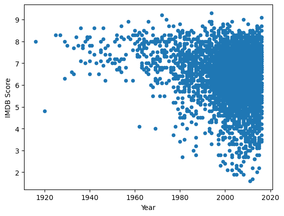

```python
# Scatter plot of "Year" and "IMDB Score"
movies_all.plot(kind = 'scatter', x = 'Year', y = "IMDB Score")
```

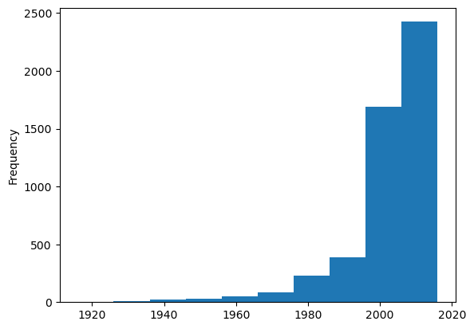

```python
# See the frequency distribution of "Year"
movies_all.Year.plot(kind = 'hist')
```

**---------------------------------------------------------------------------------------------------------------**  
**---------------------------------------------------------------------------------------------------------------**  
**---------------------------------------------------------------------------------------------------------------**  
**---------------------------------------------------------------------------------------------------------------**  
**---------------------------------------------------------------------------------------------------------------**  
**---------------------------------------------------------------------------------------------------------------**  
**---------------------------------------------------------------------------------------------------------------**  
**---------------------------------------------------------------------------------------------------------------**  
**---------------------------------------------------------------------------------------------------------------**  
**---------------------------------------------------------------------------------------------------------------**  
**---------------------------------------------------------------------------------------------------------------**  
**---------------------------------------------------------------------------------------------------------------**  
**------------------------------------------Answers to Challenges------------------------------------------**

**1.5 Practice Solution**

```python
# 1.5 Practice Solution
ex1 = array2d[[0, 1], [0, 3]]
print(f'ex1: \n{ex1}')

ex2 = array2d[:, [0,2]]
print(f'ex2: \n{ex2}')

ex3 = array2d[2]
print(f'ex3: \n{ex3}')

ex4 = array2d[[0, 1], [0, 1]]
print(f'ex4:\n{ex4}')

ex5 = array2d[[0, 2], [2, 1]]
print(f'ex5:\n {ex5}')
```

```
ex1:
[4 3]
ex2:
[[4 8]
 [2 3]
 [1 7]]
ex3:
[1 1 7 4]
ex4:
[4 6]
ex5:
 [8 1]
```

```python
import pandas as pd

import numpy as np

# a numpy array
arr = np.array(['a','c','k','l','q'])

ser = pd.Series(arr)
ser.values
```

```
array(['a', 'c', 'k', 'l', 'q'], dtype=object)
```

```python
A = ["spam", 2]
B = A
B[0] = "shrubbery"
A
```

```
['shrubbery', 2]
```

```python
A = {"spam": 2}
B = A # this is not assigning b the value {"spam": 2}, but chained together A and B, you change one, you change both
A["spam"] = "shrubbery"
B
```

```
{'spam': 'shrubbery'}
```

```python
[spam, ham] = ['yum', 'YUM']
```

```python
spam, ham
```

```
('yum', 'YUM')
```